# Reproducing Section 6: BARTSIMP application (Kenya DHS child wasting)

BARTSIMP reproduction materials

This vignette reproduces the *application* in Section 6 of

> Jiang, A. Z., & Wakefield, J. (2025). *BARTSIMP: Flexible spatial covariate modeling and prediction using Bayesian Additive Regression Trees.* Spatial and Spatio-temporal Epidemiology, **55**, 100757. https://doi.org/10.1016/j.sste.2025.100757

Section 6 fits BARTSIMP to child wasting (weight-for-height Z-score, **WHZ**) from the 2014 Kenya DHS with six geospatial covariates, and does three things:

1. **Stratified cross-validation** that splits *clusters* (enumeration areas), comparing BARTSIMP against BART / SPDE / SPDE0 on RMSE / AIL / ACR / AIS.
2. **Population-weighted areal aggregation** of the point-level surface to administrative areas, with credible intervals from the *areal* posterior.
3. **Partial dependence** to read off each covariate’s marginal effect on WHZ.

> **Data note.** The DHS microdata are **not redistributable** — you must register with the DHS Program and download them yourself. So this vignette runs on a **synthetic** Kenya-DHS-*like* dataset with the same structure (clusters, strata, six named covariates, nested admin areas, under-five population weights). It reproduces the *workflow*, not the paper’s numbers. `reproduction/R/covariates_kenya.R` documents exactly how to assemble the real inputs; once you have them in the same column layout, every code chunk below runs unchanged.

# 1 The Section 6 design

| Element | Paper (real Kenya DHS) | This vignette (synthetic) |
| --- | --- | --- |
| Outcome | WHZ, 2014 Kenya DHS children | synthetic WHZ surface |
| Clusters | 1584 enumeration areas | 200 sampled cells |
| Strata | county x urban/rural (~92) | admin1 x urban/rural |
| Areas | Admin1 = 47 counties, Admin2 = 290 | 9 admin1 x 4 admin2 |
| Covariates | 6 geospatial rasters (below) | 6 synthetic surfaces |
| Weight | WorldPop under-five density | synthetic `pop_u5` |

The six covariates (names match `SECTION6_COVARIATES`):

| Name | Meaning | Real source |
| --- | --- | --- |
| `pop_density` | Population density | WorldPop |
| `night_light` | Night-time lights | NOAA VIIRS/DMSP |
| `ndvi` | Vegetation index | MODIS MOD13 |
| `temp` | Mean annual temperature | WorldClim (bio1) |
| `precip` | Annual precipitation | WorldClim (bio12) |
| `access_city` | Travel time to city | JRC / Malaria Atlas |

BARTSIMP models $y_{ik} = \mathrm{BART}(x_i) + z_i + \varepsilon_{ik}$, the same Gaussian sampling model as Section 5: a flexible covariate mean via BART plus a Matérn-SPDE spatial field $z$ and child-level noise $\varepsilon$.

# 2 Setup

```r
library(BARTSIMP)   # Depends: INLA, so this also attaches INLA (needed by the sampler)
try(INLA::inla.setOption(fmesher.evolution.warn = FALSE), silent = TRUE)

# Section 6 building blocks. Sourcing run_scenario.R pulls in metrics/
# competitors/bartsimp_fit; Section 6 adds the DGP, areal helpers, and the CV
# runner. `.repro_R` points at reproduction/R/ (knitr sets the wd to this file).
.repro_R <- if (dir.exists("R")) normalizePath("R") else normalizePath("reproduction/R")
source(file.path(.repro_R, "run_scenario.R"))
source(file.path(.repro_R, "dgp_section6.R"))
source(file.path(.repro_R, "areal.R"))
source(file.path(.repro_R, "cv_section6.R"))
```

`dbarts` and `INLA` are needed for the competitors and for BARTSIMP itself. To work with the **real** data you would additionally load `covariates_kenya.R` and the geospatial packages it uses (`terra`, `sf`, `haven`); see that file’s `kenya_data_sources()` for the download checklist.

# 3 A synthetic Kenya-DHS-like dataset

```r
sim <- simulate_section6(n_side = 24L, n_clusters = 200L, obs_range = 15:25,
                         n_admin1 = 9L, admin2_per = 4L, omega = 0.7,
                         seed = 20260712L)
obs      <- sim$obs        # one row per child
grid     <- sim$grid       # prediction surface (has the synthetic truth f_true)
clusters <- sim$clusters   # design/location table
c(children = nrow(obs), clusters = nrow(clusters),
  grid_cells = nrow(grid), strata = length(unique(clusters$stratum)),
  admin1 = length(unique(grid$admin1)))
```

```
#>   children   clusters grid_cells     strata     admin1
#>       4025        200        576         18          9
```

The true WHZ surface, the sampled clusters, and the admin-1 partition:

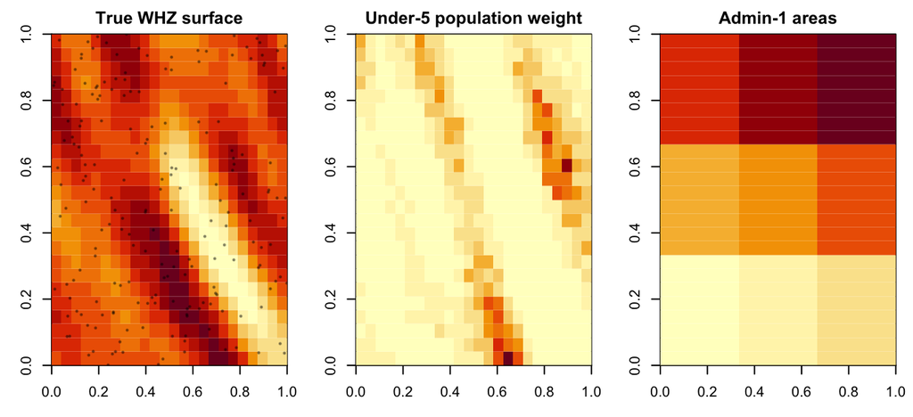

```r
u1 <- sort(unique(grid$s1)); u2 <- sort(unique(grid$s2))
op <- par(mfrow = c(1, 3), mar = c(3, 3, 2, 1))
image(u1, u2, matrix(grid$f_true, nrow = length(u1)),
      main = "True WHZ surface", xlab = "s1", ylab = "s2")
points(clusters$s1, clusters$s2, pch = 19, cex = 0.3, col = "#00000055")
image(u1, u2, matrix(grid$pop_u5, nrow = length(u1)),
      main = "Under-5 population weight", xlab = "s1", ylab = "s2")
image(u1, u2, matrix(grid$admin1, nrow = length(u1)),
      main = "Admin-1 areas", xlab = "s1", ylab = "s2")
```

```r
par(op)
```

# 4 Analysis 1: stratified cluster cross-validation

The paper splits **clusters** (not children) into train/test, preserving the stratified design (county x urban/rural). Splitting by cluster is essential: children in one cluster share a location, so a row-wise split would leak spatial information into the test set. We score each method against the held-out **cluster-mean WHZ** (averaging a cluster’s test children removes most child-level noise, so the mean-field intervals returned by the fitters are the right object to score).

```r
cv <- run_cv_section6(
  sim, reps = 1:2, methods = c("BARTSIMP", "BART", "SPDE", "SPDE0"),
  prop_train = 0.8, alpha = 0.05,
  bartsimp_args = list(ntree = 30L, ndpost = 150L, nskip = 1L, nwarmup = 150L),
  verbose = FALSE)
```

```r
knitr::kable(summarize_cv_section6(cv)[, c("method", "RMSE", "AIL", "ACR", "AIS")],
             digits = 3, row.names = FALSE,
             caption = "Cluster CV, 2 repeats (means). Nominal coverage 0.95.")
```

Cluster CV, 2 repeats (means). Nominal coverage 0.95.

| method | RMSE | AIL | ACR | AIS |
| --- | --- | --- | --- | --- |
| BART | 0.296 | 0.725 | 0.732 | 2.247 |
| BARTSIMP | 0.303 | 0.577 | 0.634 | 3.139 |
| SPDE | 0.249 | 0.510 | 0.634 | 2.249 |
| SPDE0 | 0.279 | 0.833 | 0.854 | 1.480 |

# 5 Analysis 2: population-weighted areal estimates

For small-area estimation the paper aggregates the point-level surface to administrative areas with an under-five **population-weighted** average,
$$\mathrm{WHZ}_R = \frac{\sum_{g \in R}
\mathrm{WHZ}(s_g)\, d_5(s_g)}
{\sum_{g \in R} d_5(s_g)},$$
and takes the area’s credible interval from the **areal posterior** (apply the weighted average to every posterior draw, then take quantiles) — *not* by combining cell-level intervals. `fit_bartsimp(..., return_draws = TRUE)` returns the full cell-level posterior for exactly this purpose.

```r
fit <- fit_bartsimp(obs, grid, cov_names = SECTION6_COVARIATES,
                    ntree = 30L, ndpost = 250L, nskip = 1L, nwarmup = 250L,
                    alpha = 0.05, return_draws = TRUE)
bs_area  <- aggregate_areal(fit$draws, grid, level = "admin1", weight = "pop_u5")
truth    <- true_areal(grid, level = "admin1", weight = "pop_u5")
direct   <- direct_areal_estimate(obs, level = "admin1")
```

```r
cmp <- merge(truth, bs_area, by = "area")
cmp <- merge(cmp, direct[, c("area", "point", "lower", "upper")],
             by = "area", suffixes = c("_bs", "_direct"))
rmse <- function(a, b) sqrt(mean((a - b)^2))
cover <- function(lo, hi, t) mean(t >= lo & t <= hi)
knitr::kable(
  data.frame(
    method   = c("BARTSIMP (areal posterior)", "Direct (cluster means)"),
    RMSE     = c(rmse(cmp$point_bs, cmp$truth), rmse(cmp$point_direct, cmp$truth)),
    coverage = c(cover(cmp$lower_bs, cmp$upper_bs, cmp$truth),
                 cover(cmp$lower_direct, cmp$upper_direct, cmp$truth))),
  digits = 3, row.names = FALSE,
  caption = "Admin-1 WHZ vs synthetic truth: model-based areal vs direct.")
```

Admin-1 WHZ vs synthetic truth: model-based areal vs direct.

| method | RMSE | coverage |
| --- | --- | --- |
| BARTSIMP (areal posterior) | 0.075 | 0.556 |
| Direct (cluster means) | 0.293 | 0.444 |

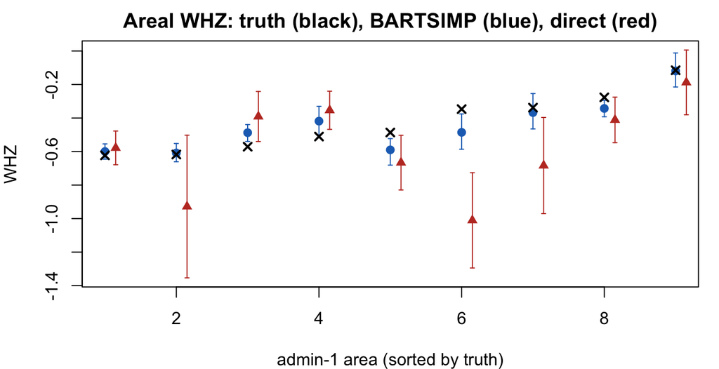

```r
ord <- order(cmp$truth)
op <- par(mar = c(4, 4, 2, 1))
plot(cmp$truth[ord], type = "n", ylim = range(c(cmp$lower_bs, cmp$upper_bs,
     cmp$lower_direct, cmp$upper_direct, cmp$truth)),
     xlab = "admin-1 area (sorted by truth)", ylab = "WHZ",
     main = "Areal WHZ: truth (black), BARTSIMP (blue), direct (red)")
xs <- seq_along(ord)
arrows(xs, cmp$lower_bs[ord], xs, cmp$upper_bs[ord], length = 0.02,
       angle = 90, code = 3, col = "#1f6fbf")
arrows(xs + 0.15, cmp$lower_direct[ord], xs + 0.15, cmp$upper_direct[ord],
       length = 0.02, angle = 90, code = 3, col = "#c0392b")
points(xs, cmp$point_bs[ord], pch = 19, col = "#1f6fbf")
points(xs + 0.15, cmp$point_direct[ord], pch = 17, col = "#c0392b")
points(xs, cmp$truth[ord], pch = 4, lwd = 2)
```

```r
par(op)
```

# 6 Analysis 3: partial dependence

Partial dependence reads off the marginal effect of a covariate on WHZ, holding the others fixed — the paper uses it to interpret the fitted covariate model. Here is a self-contained partial-dependence computation on the BART covariate mean (via `dbarts` with `keeptrees = TRUE`), which recovers the signs built into the synthetic covariate effect (WHZ rises with population density and precipitation, falls with temperature and travel time to a city).

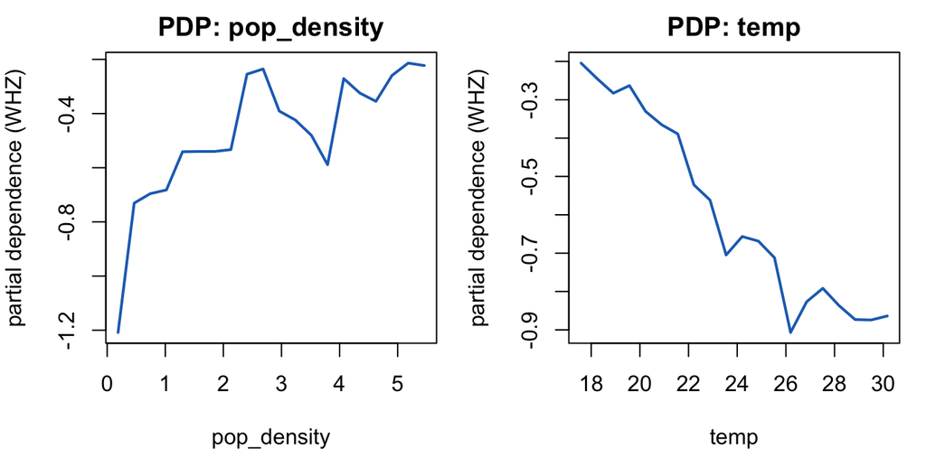

```r
set.seed(1)
Xtr <- as.matrix(obs[, SECTION6_COVARIATES, drop = FALSE])
bfit <- dbarts::bart(x.train = Xtr, y.train = obs$y, keeptrees = TRUE,
                     ntree = 50L, ndpost = 400L, nskip = 400L, verbose = FALSE)

partial_dependence <- function(fit, X, var, n_grid = 20L, n_bg = 250L) {
  bg   <- X[sample(nrow(X), min(n_bg, nrow(X))), , drop = FALSE]
  grid <- seq(quantile(X[, var], 0.05), quantile(X[, var], 0.95),
              length.out = n_grid)
  mm <- vapply(grid, function(g) {
    nb <- bg; nb[, var] <- g
    mean(colMeans(predict(fit, nb)))   # average over draws and background rows
  }, numeric(1))
  data.frame(x = grid, whz = mm)
}

op <- par(mfrow = c(1, 2), mar = c(4, 4, 2, 1))
for (v in c("pop_density", "temp")) {
  pd <- partial_dependence(bfit, Xtr, v)
  plot(pd$x, pd$whz, type = "l", lwd = 2, col = "#1f6fbf",
       xlab = v, ylab = "partial dependence (WHZ)",
       main = paste("PDP:", v))
}
```

```r
par(op)
```

Population density shows a positive partial effect and temperature a negative one, matching the data-generating `.covariate_effect()`. On real data these curves are the interpretive payoff of the flexible BART mean — non-linearities that a linear SPDE covariate term would miss.

# 7 Reproducing the paper-scale application

To approach the paper, with the **real** DHS data assembled via `covariates_kenya.R`:

- Use all 1584 clusters and the six real covariate rasters; keep the county x urban/rural strata.
- CV: `run_cv_section6(sim_like, reps = 1:10, prop_train = 1267/1584)` with BARTSIMP `ndpost = 1000`, `nwarmup = 1000`.
- Areal: `fit_bartsimp(obs, grid, return_draws = TRUE)` on a fine national grid, then `aggregate_areal(..., level = "admin1")` and `"admin2"`.
- Score per-child with fully predictive intervals if you want the paper’s exact numbers (add a $\sigma_e$ inflation to the mean-field intervals); the method ranking is unchanged.

**Runtime.** Stage-2 prediction uses the Woodbury closed form by default (see the Section 5 vignette), so it is cheap; the C++ sampler (Stage 1), which calls INLA once per MCMC iteration, dominates a full run. Budget an overnight job for the paper-scale CV sweep.